# Statistical inference with the GSS data

## Setup

### Load packages

```r
library(ggplot2)
library(dplyr)
library(statsr)
```

### Load data

```r
load("~/Downloads/_5db435f06000e694f6050a2d43fc7be3_gss.Rdata")
```

## Part 1: Data

The GSS gathers data on contemporary American society in order to monitor and explain trends and constants in attitudes, behaviors, and attributes. Hundreds of trends have been tracked since 1972. In addition, since the GSS adopted questions from earlier surveys, trends can be followed for up to 70 years.

The GSS contains a standard core of demographic, behavioral, and attitudinal questions, plus topics of special interest. Among the topics covered are civil liberties, crime and violence, intergroup tolerance, morality, national spending priorities, psychological well-being, social mobility, and stress and traumatic events.

Altogether the GSS is the single best source for sociological and attitudinal trend data covering the United States. It allows researchers to examine the structure and functioning of society in general as well as the role played by relevant subgroups and to compare the United States to other nations.

The GSS aims to make high-quality data easily accessible to scholars, students, policy makers, and others, with minimal cost and waiting.

The survey is conducted face-to-face with an in-person interview by NORC at the University of Chicago. The survey was conducted every year from 1972 to 1994 (except in 1979, 1981, and 1992). Since 1994, it has been conducted every other year. The survey takes about 90 minutes to administer. As of 2014, 30 national samples with 59,599 respondents and 5,900+ variables have been collected.

The GSS is however an **observational study** - with no explicit random assignments to treatments - so all relationships indicated may indicate **association or correlation** but not **causation**

## Part 2: Research question

I think majority of the people follow a religion. Let us see if there is a relation or association between how higher degree does the respondent have and how often he/she attends a religious events.

### Data

**degree:** is a categorical variable represents educational qualification of the respondent in terms of how higher degree has he/she recieved. **attend** is a categorical variable representing how often a person attends a religious event.

## Part 3: Exploratory data analysis

```r
gss_religion  <- gss %>% filter(!is.na(degree) & !is.na(attend)) %>% select(degree,attend)
dim(gss_religion)
```

```
## [1] 46267     2
```

```r
table(gss_religion$attend)
```

```
##
##            Never   Lt Once A Year      Once A Year Sevrl Times A Yr
##                0             4276             7384             7081
##     Once A Month     2-3X A Month  Nrly Every Week       Every Week
##             4000             4974             3133            11162
## More Thn Once Wk
##             4257
```

```r
religion_table <- table(gss_religion$degree)
prop.table(religion_table)
```

```
##
## Lt High School    High School Junior College       Bachelor       Graduate
##     0.20271468     0.52475847     0.05641170     0.14641105     0.06970411
```

There is no entry where a respondent never attends a religious meetup. Most people in the group attend the religious event once a week. Also 50% people in our study have a high school degree.

```r
religion_table2 <-table(gss_religion$degree,gss_religion$attend)
prop.table(religion_table2)
```

```
##
##                        Never Lt Once A Year Once A Year Sevrl Times A Yr
##   Lt High School 0.000000000    0.020273629 0.030950786      0.029632351
##   High School    0.000000000    0.050467936 0.086454709      0.082521019
##   Junior College 0.000000000    0.004819850 0.008818380      0.008559016
##   Bachelor       0.000000000    0.011174271 0.022780816      0.021743359
##   Graduate       0.000000000    0.005684397 0.010590702      0.010590702
##
##                  Once A Month 2-3X A Month Nrly Every Week  Every Week
##   Lt High School  0.016534463  0.022002723     0.015345711 0.046577474
##   High School     0.044999676  0.055892969     0.033501200 0.123241187
##   Junior College  0.005684397  0.006829922     0.003631098 0.013357252
##   Bachelor        0.013162729  0.015777984     0.010352951 0.039315279
##   Graduate        0.006073443  0.007002831     0.004884691 0.018760672
##
##                  More Thn Once Wk
##   Lt High School      0.021397540
##   High School         0.047679772
##   Junior College      0.004711782
##   Bachelor            0.012103659
##   Graduate            0.006116671
```

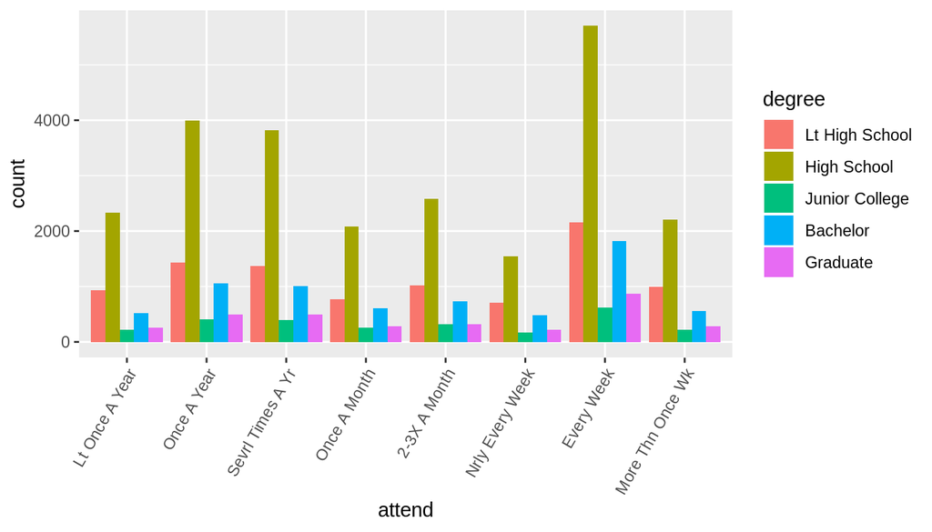

```r
g <- ggplot(data = gss_religion, aes(x=attend))
g <- g + geom_bar(aes(fill=degree), position = "dodge")
g + theme(axis.text.x = element_text(angle=60,hjust = 1))
```

We see almost similar proportion of people with similar pattern of attending religious events with different degrees.

## Part 4: Inference

### Hypothesis

*Null Hyposthesis:* *H_0* The number of times a respondent attends a religious event and the education qualification of a respondent are independent.

*Alternative Hypothesis:* *H_a* The number of times a respondent attends a religious event and the education qualification of a respondent are dependent.

### Checking Conditions:

```r
chisq.test(gss_religion$degree,gss_religion$attend)$expected
```

```
##                    gss_religion$attend
## gss_religion$degree Lt Once A Year Once A Year Sevrl Times A Yr
##      Lt High School       866.8080   1496.8452        1435.4226
##      High School         2243.8672   3874.8165        3715.8147
##      Junior College       241.2164    416.5440         399.4512
##      Bachelor             626.0536   1081.0992        1036.7366
##      Graduate             298.0548    514.6951         493.5748
##                    gss_religion$attend
## gss_religion$degree Once A Month 2-3X A Month Nrly Every Week Every Week
##      Lt High School     810.8587    1008.3028        635.1051  2262.7012
##      High School       2099.0339    2610.1486       1644.0683  5857.3540
##      Junior College     225.6468     280.5918        176.7378   629.6674
##      Bachelor           585.6442     728.2486        458.7058  1634.2401
##      Graduate           278.8164     346.7082        218.3830   778.0373
##                    gss_religion$attend
## gss_religion$degree More Thn Once Wk
##      Lt High School         862.9564
##      High School           2233.8968
##      Junior College         240.1446
##      Bachelor               623.2718
##      Graduate               296.7304
```

So the condition that there must be 5 in each category is satisfied.

Now performing the chi-squared test for independence.

```r
chisq.test(gss_religion$degree,gss_religion$attend)
```

```
##
##  Pearson's Chi-squared test
##
## data:  gss_religion$degree and gss_religion$attend
## X-squared = 150.46, df = 28, p-value < 2.2e-16
```